# Indel Signature InsDel23

# InsDel23

(corresponds to 83-type signature C_ID23)

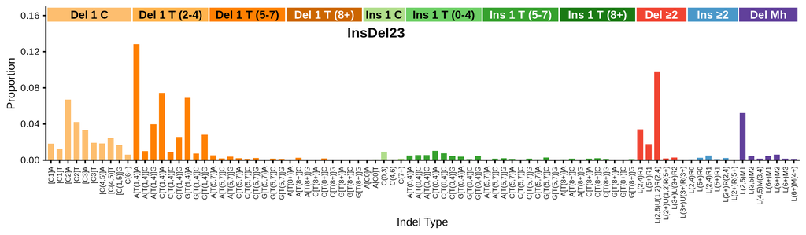

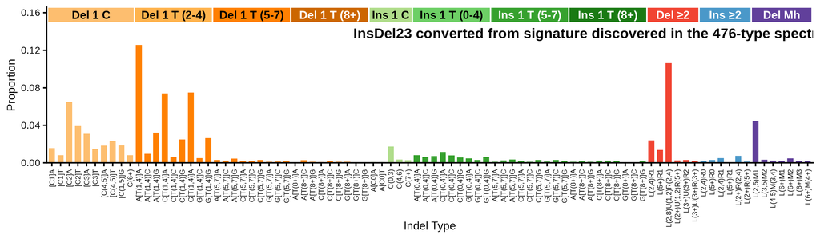

89-type spectrum of the linking tumor SP102957 | cosine similarity to InsDel23: 0.9606

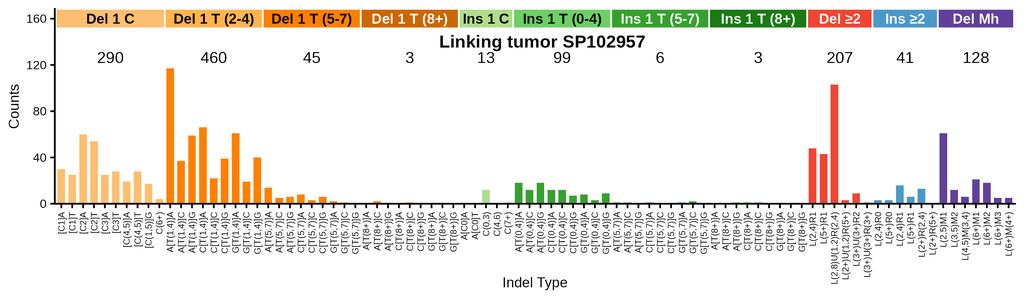

**Click to view decomposition of the linking tumor spectrum**

Partial mutation signature of SP102957 due to InsDel23

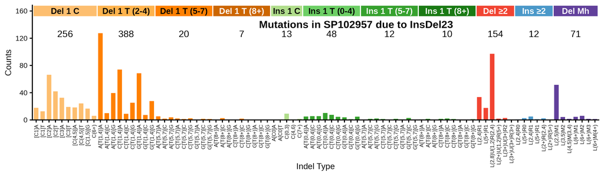

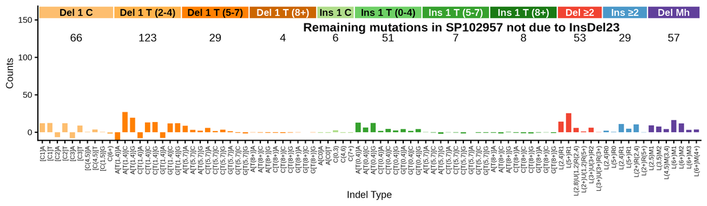

Max neg fraction (maximum allowed negative residual count as fraction of total): 0.05  
N subtract (mutation count assigned to signature): 991.5  
N residual (mutation count in residual “partial spectrum”): 303.5  
Total negative (sum of negative residual mutation counts): 64.6  
N negative channels (number of channels with negative residual): 37  
P(≥ total negative) (Monte Carlo estimated probability that negative-binomial-sampled spectra from the signature contributing N subtract mutations would produce a total negative count >= the observed Total negative; higher number means not surprising): 0.838

**Per-channel residual breakdown**

| Channel | Spectrum | Sig_Count | Residual | Sig_Prop |
| --- | --- | --- | --- | --- |
| [Del(C):R1]A | 30 | 17.9 | 12.1 | 0.01809 |
| [Del(C):R1]T | 25 | 12.7 | 12.3 | 0.01278 |
| [Del(C):R2]A | 60 | 66.4 | -6.4 | 0.06696 |
| [Del(C):R2]T | 54 | 41.9 | 12.1 | 0.04229 |
| [Del(C):R3]A | 25 | 32.7 | -7.7 | 0.03301 |
| [Del(C):R3]T | 28 | 19.1 | 8.9 | 0.01924 |
| [Del(C):R(4,5)]A | 19 | 18.3 | 0.7 | 0.01849 |
| [Del(C):R(4,5)]T | 28 | 24.3 | 3.7 | 0.02452 |
| [Del(C):R(1,5)]G | 17 | 16.5 | 0.5 | 0.01665 |
| Del(C):R(6,9) | 4 | 6.1 | -2.1 | 0.00613 |
| A[Del(T):R(1,4)]A | 117 | 127.3 | -10.3 | 0.12838 |
| A[Del(T):R(1,4)]C | 37 | 10.0 | 27 | 0.01006 |
| A[Del(T):R(1,4)]G | 59 | 39.5 | 19.5 | 0.03980 |
| C[Del(T):R(1,4)]A | 66 | 73.9 | -7.9 | 0.07451 |
| C[Del(T):R(1,4)]C | 22 | 8.9 | 13.1 | 0.00896 |
| C[Del(T):R(1,4)]G | 39 | 25.4 | 13.6 | 0.02557 |
| G[Del(T):R(1,4)]A | 61 | 68.5 | -7.5 | 0.06908 |
| G[Del(T):R(1,4)]C | 19 | 7.2 | 11.8 | 0.00729 |
| G[Del(T):R(1,4)]G | 40 | 27.8 | 12.2 | 0.02802 |
| A[Del(T):R(5,7)]A | 14 | 5.3 | 8.7 | 0.00531 |
| A[Del(T):R(5,7)]C | 5 | 1.7 | 3.3 | 0.00176 |
| A[Del(T):R(5,7)]G | 6 | 3.8 | 2.2 | 0.00385 |
| C[Del(T):R(5,7)]A | 8 | 2.1 | 5.9 | 0.00213 |
| C[Del(T):R(5,7)]C | 3 | 1.3 | 1.7 | 0.00129 |
| C[Del(T):R(5,7)]G | 6 | 2.5 | 3.5 | 0.00248 |
| G[Del(T):R(5,7)]A | 2 | 0.7 | 1.3 | 0.00067 |
| G[Del(T):R(5,7)]C | 1 | 1.6 | -0.6 | 0.00161 |
| G[Del(T):R(5,7)]G | 0 | 1.4 | -1.4 | 0.00146 |
| A[Del(T):R(8,)]A | 0 | 0.1 | -0.1 | 0.00015 |
| A[Del(T):R(8,)]C | 2 | 2.5 | -0.5 | 0.00255 |

[output cut: 59 more lines]

## 476-type representations corresponding to InsDel23

Extracted 476-type signature corresponding to InsDel23

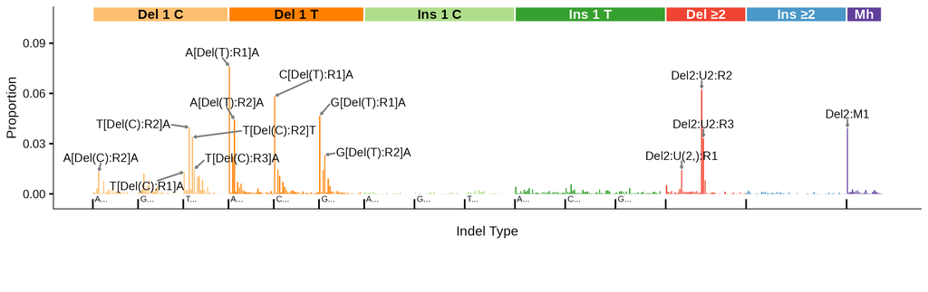

476-type spectrum of the linking tumor SP102957; cosine similarity to the extracted 476-type signature is 0.926

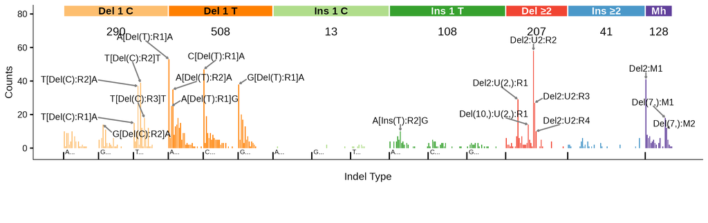

## 83-type signature corresponding to InsDel23 (C_ID23)

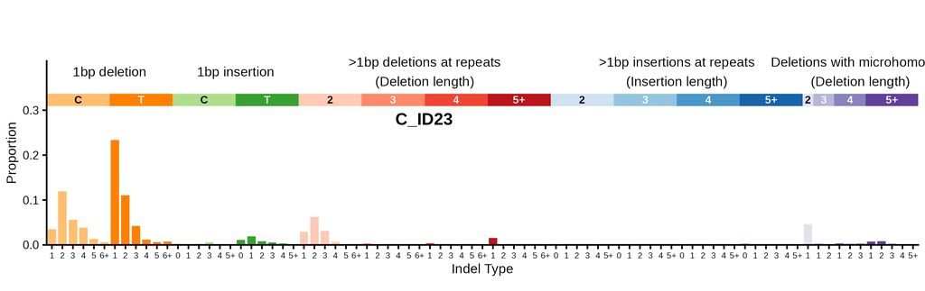

83-type signature converted from signature discovered in the 476-type spectra (using bipartite matching optimization) | cosine similarity to C_ID23: 0.9906

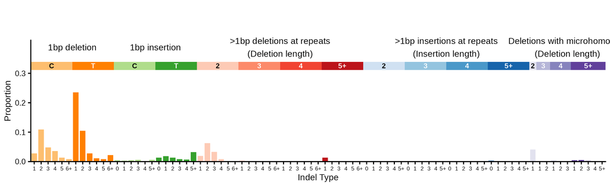

**Click to see flow diagrams: 476-type to 83-type collapse**

These Sankey diagrams show how the 476-type mutation categories are redistributed to 83-type categories using bipartite matching. We only show the diagrams for insertions or deletions of > 1 base because it is for these indels that 476-type categories map to > 1 83-type category.

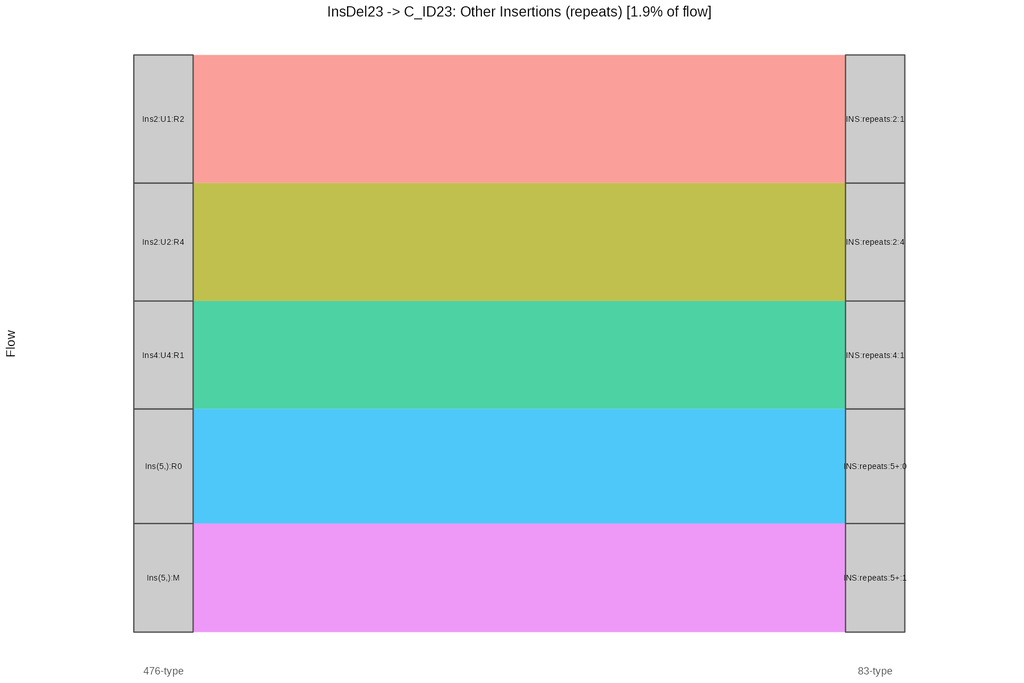

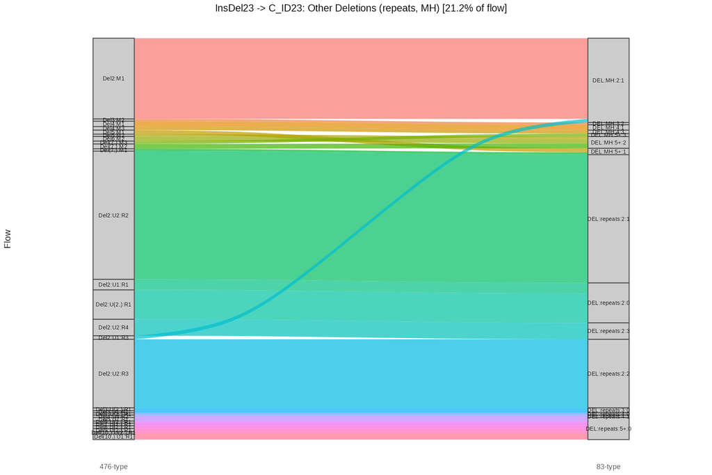

83-type spectrum of the linking tumor SP102957 | cosine similarity to C_ID23: 0.9664

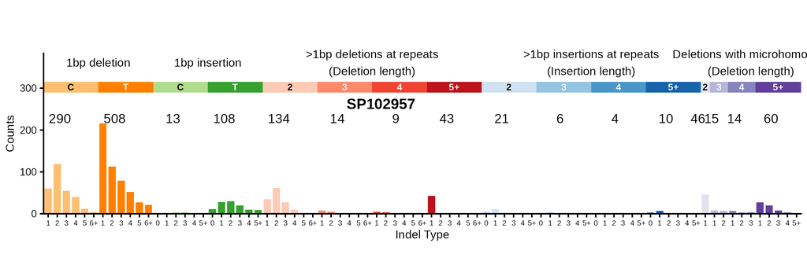

### Similar COSMIC signatures

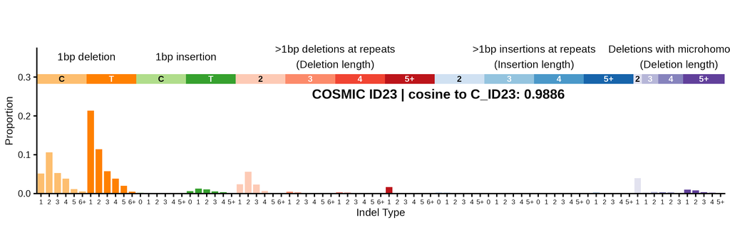